# Informe 8: Prueba Keras en Servidor UOC

Carmen Lebrero Cia

Este informe se dividirá en dos partes. Una primera en la que instalaremos rstudio-server, una extensión que nos permitirá utilizar RStudio en el navegador y abrir sesiones de R de nuestro servidor. Así podremos utilizar paquetes de entrenamiento de redes que necesitan visualizado como `tfruns`.

# Instalación

## Instalación rstudio-server

Para esto seguiremos los pasos descritos en:

1. https://rstudio.com/products/rstudio/download-server/debian-ubuntu/
2. https://akhvorov.rbind.io/2019/11/05/running-rstudio-on-an-ubuntu-server-over-ssh/

Nuestra máquina es un un Ubuntu 20.04, por lo que seguiremos los pasos del apartado “Install for Debian 10 / Ubuntu 18 / Ubuntu 20”.

```
sudo apt-get install gdebi-core
wget https://download2.rstudio.org/server/bionic/amd64/rstudio-server-1.3.1093-amd64.deb
sudo gdebi rstudio-server-1.3.1093-amd64.deb
```

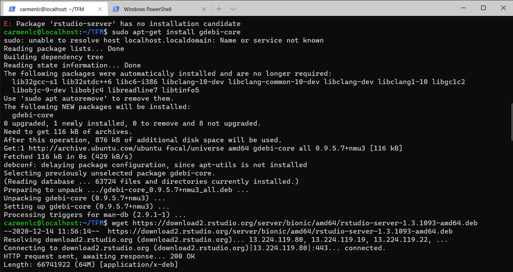

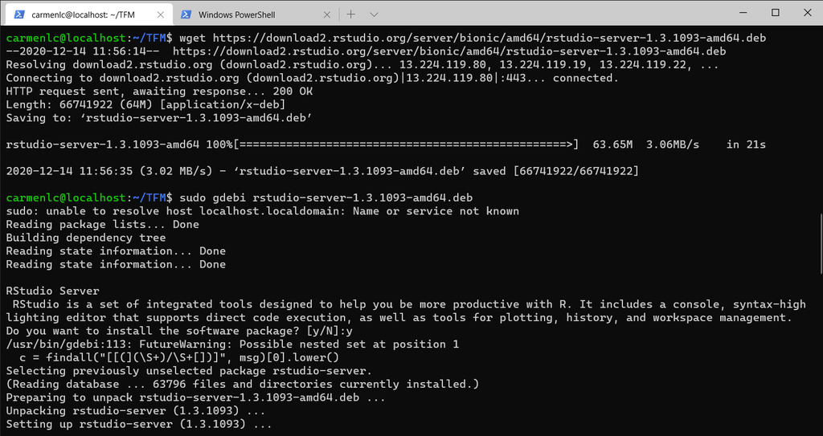

Tras la instalación tenemos que “activar” la aplicación y el tunel entre el servidor y el browser de nuestro ordenador. Lo primero que tenemos que hacer es crear una contraseña con la que podremos entrar luego en la aplicación de RStudio del navegador.

En el servidor Ubuntu:

```
passwd carmenlc
rstudio-server start
```

En la consola de comandos de windows:

```
ssh -f -N -L 1234:localhost:8787 carmenlc@uocsev
```

En el navegador del ordenador:

```
http://localhost:1234/auth-sign-in
```

Entonces, en el navegador podemos entrar con nuestro nombre de usuario y contraseña a la aplicación de RStudio.

[figure not shown]

## Instalación Keras y TensorFlow

Tenemos que instalar tanto el paquete Keras como TensorFlow con `install_keras()`.

```
install.packages("keras")
library(keras)
install_keras()
```

# Ejemplo MNIST

Vamos a aprender lo básico de Keras utilizando un ejemplo sencillo: reconocimiento de dígitos manuscritos del dataset MNIST.

## Preparando los datos

```
mnist <- dataset_mnist()
x_train <- mnist$train$x
y_train <- mnist$train$y
x_test <- mnist$test$x
y_test <- mnist$test$y
```

Vamos a preparar los datos para entrenar el modelo, cambiando las dimensiones de los datos y reescalandolos.

```
# reshape
dim(x_train) <- c(nrow(x_train), 784)
dim(x_test) <- c(nrow(x_test), 784)
# rescale
x_train <- x_train / 255
x_test <- x_test / 255
```

Y ahora preparamos los vectores y_train e y_test que tienen las etiquetas.

```
y_train <- to_categorical(y_train, 10)
y_test <- to_categorical(y_test, 10)
```

## Definiendo el modelo

La estructura de datos de Keras es un modelo que organiza capas. El modelo más sencillo es un modelo con capas organizadas de forma secuencial.

```
model <- keras_model_sequential()
model %>%
layer_dense(units = 256, activation = "relu", input_shape = c(784)) %>%
layer_dropout(rate = 0.4) %>%
layer_dense(units = 128, activation = "relu") %>%
layer_dropout(rate = 0.3) %>%
layer_dense(units = 10, activation = "softmax")
summary(model)
```

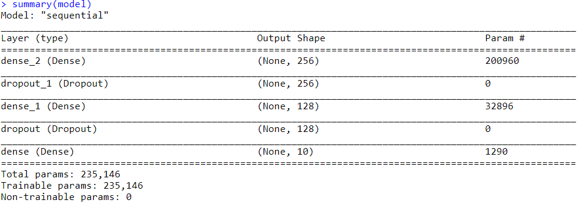

Ahora compilamos el modelo con las funciones de pérdida y optimizadores:

```
model %>% compile(
loss = "categorical_crossentropy",
optimizer = optimizer_rmsprop(),
metrics = c("accuracy")
)
```

## Entrenamiento y evaluación

```
history <- model %>% fit(
x_train, y_train,
epochs = 30, batch_size = 128,
validation_split = 0.2
)
```

El objeto `history` devuelto por la función `fit()` incluye los datos de métricas de pérdida y de precisión y puede visualizarse en una gráfica.

```
model %>% evaluate(x_test, y_test,verbose = 0)
```

[figure not shown]

# Conclusión

En el próximo informe (Informe 9) se desarrollarán modelos supervisados de las tres ómicas por separado para ver su rendimiento e intentar encontrar la mejor arquitectura. El siguiente paso será crear un modelo que integre los tres datos (Ver página 222 del libro de Deep Learning con R de François Chollet con J.J. Allaire).